# Relatório de Pinguins

Um breve exemplo de relatório a partir da base Palmer Penguins

Viktor Chagas, Universidade Federal Fluminense [^1]

Abstract

Este é um exemplo de relatório de final de curso a ser entregue para a disciplina de Introdução à Análise de Pesquisa Quantitativa, semestre letivo 2020.2, na graduação em Estudos de Mídia.

# Introdução

A base de dados Palmer Penguins é um pacote que se destina a apresentar um *dataset* com algumas variáveis que podem ser úteis para ensinar comandos básicos para análise estatística e ciência de dados. Os dados foram originalmente coletados e tornados disponíveis pela pesquisadora Kristen Gorman e pela Palmer Station Antarctica LTER, que integra a rede Long Term Ecological Research Network.

Os dados com que este relatório trabalha contém 333 observações, de um total de 344 casos na base original. Foram descartadas observações em que algumas variáveis eram nulas ou não disponíveis. A tabela de dados contém oito diferentes variáveis, que incluem a espécie dos pinguins, a ilha em que foram avistados, medidas corporais, sexo, e ano de registro. Com base nessas 333 observações, procederemos nossas análises.

# Análise geral dos dados

Há alguns pontos interessantes a serem observados a respeito de nossos dados. O primeiro deles é que há um certo equilíbrio entre os sexos dos pinguins na amostra analisada. São 165 pinguins fêmeas e 168 pinguins machos, o que nos permite uma série de comparações interessantes entre os dois sexos.

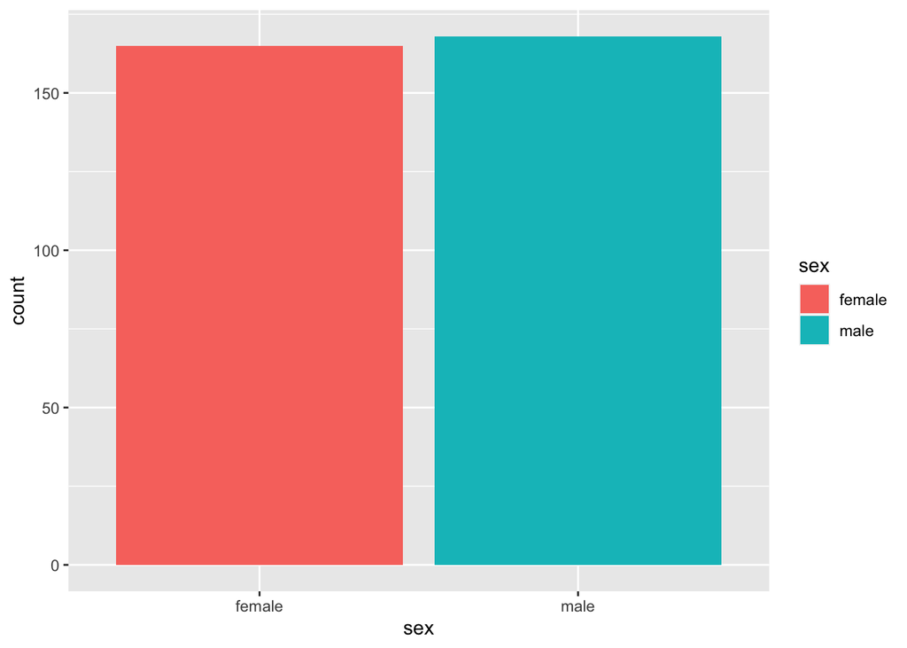

Também é possível avaliarmos e compararmos os dados conforme a espécie dos pinguins. O *dataset* nos apresenta três diferentes espécies de pinguins: Adélie, Chinstrap e Gentoo. Como veremos, há profundas diferenças entre cada espécie no que tange às suas medidas corporais, por exemplo. Na amostra, temos a seguinte proporção para cada espécie:

|  | species | n | perc |
| --- | --- | --- | --- |
| 1 | Adelie | 146 | 43.84384 |
| 2 | Chinstrap | 68 | 20.42042 |
| 3 | Gentoo | 119 | 35.73574 |

Ou seja, os pinguins da espécie Adélie são a maioria entre os dados coletados, correspondendo a 43,8% (N = 146) do banco. Já os pinguins da espécie Chinstrap são minoritários, correspondendo a somente 20,4% (N = 68) dos dados. Mesmo assim, uma avaliação comparativa entre as espécies não só é possível, como é interessante para que tenhamos uma visão segmentada mais clara sobre as diferenças e semelhanças entre os indivíduos.

Outro dado que vale ressaltar é que a amostra foi composta a partir de casos registrados em três anos distintos, de 2007 a 2009. O último desses anos é o que possui mais observações, conforme vemos no gráfico abaixo:

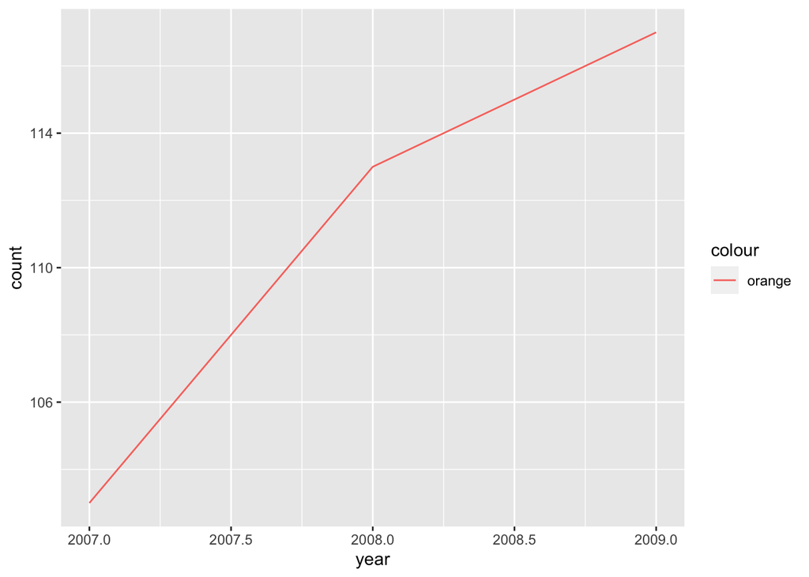

Dadas as limitações dos dados de que dispomos, não é possível afirmar qualquer relação direta de causalidade, mas uma hipótese possível de ser traçada a partir deste incremento de observações é de que a população de pinguins tem migrado substancialmente para os locais monitorados pela estação de trabalho nos últimos anos. Entretanto, é possível também que as técnicas de observação e registro dos animais tenham se aprimorado e isso tenha levado a um aumento na documentação dos casos.

# Diferenças entre os sexos

Os indivíduos apresentam variações em suas medidas corporarias de acordo com o sexo. Os pinguins machos têm geralmente um comprimento e uma altura do bico maiores que os pinguins fêmeas. O tamanho das nadadeiras também é levemente maior. E a massa corporal é, dentre esses índices, aquele que mais acentuadamente varia em função do sexo. Na tabela e nos gráficos abaixo, é possível conferir essas variações em detalhes.

| sex | bill_length_mm | bill_depth_mm | flipper_length_mm | body_mass_g |
| --- | --- | --- | --- | --- |
| female | 42.09697 | 16.42545 | 197.3636 | 3862.273 |
| male | 45.85476 | 17.89107 | 204.5060 | 4545.685 |

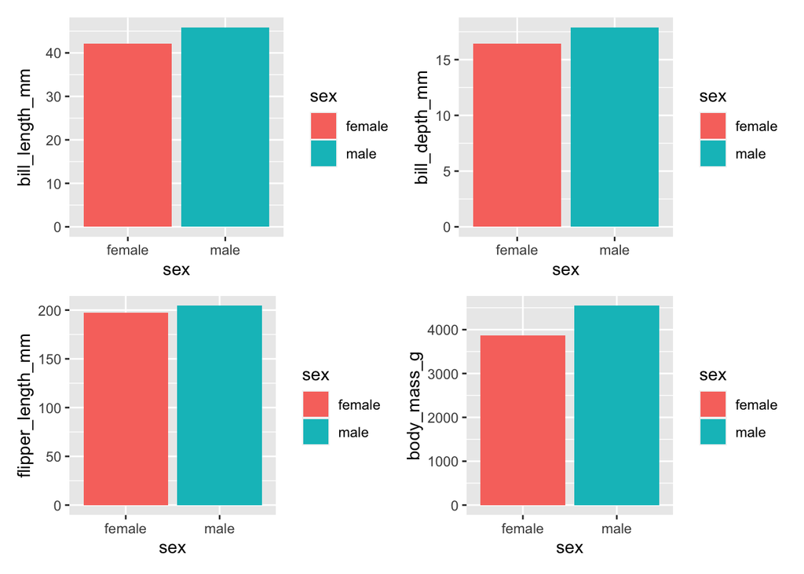

# Diferença entre as espécies

Como já apontado, existem três espécies de pinguins documentadas na amostra avaliada. Tais espécies apresentam diferenças significativas entre si. Abaixo, identificamos algumas dessas diferenças.

O dado que mais chama a atenção é que a espécie Gentoo é destacadamente aquela que tem mais massa corporal, ou seja, é mais pesada, e também aquela com as maiores medidas. Na comparação entre massa corporal e tamanho das nadadeiras, a espécie Gentoo aparece como aquela com maiores tendências nos padrões observados.

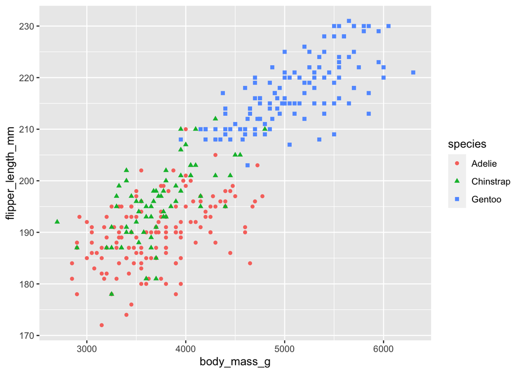

A massa corporal da espécie Gentoo sugere que o tamanho dos indivíduos desta espécie é bastante superior aos das demais espécies. No histograma facetado abaixo, é possível comparar essas tendências.

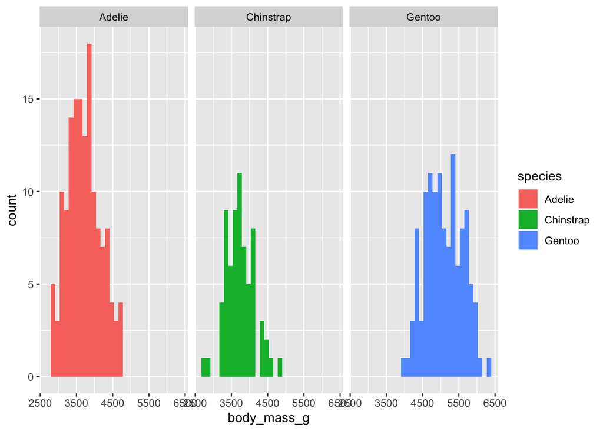

# Considerações finais

Este relatório é apenas um exemplo do que é possível ser feito e apresentado com R Markdown. Naturalmente, a base de dados Palmer Penguins permite um conjunto muito maior de cruzamentos e visualizações de seus dados do que aquelas que apresentamos aqui neste relatório. Contudo, apesar dessas limitações, algumas conclusões são possíveis a partir dos gráficos e tabelas que dispomos acima.

Em primeiro lugar, há um equilíbrio na contagem de indivíduos na amostra de acordo com os seus sexos. O número de pinguins machos é muito próximo do número de pinguins fêmeas. Apesar disso, as diferenças entre os sexos saltam aos olhos. Os pinguins machos são maiores e mais pesados que as fêmeas no geral, ainda que haja variações entre as espécies.

As comparações são interessantes para percebermos características que distinguem os indivíduos no geral e de acordo com suas espécies. Novos estudos sobre esses dados, porém, podem nos levar a conclusões mais precisas e aprofundadas.

[^1]: Professor e pesquisador do Programa de Pós-Graduação em Comunicação da Universidade Federal Fluminense. Doutor em História, Política e Bens Culturais pelo Centro de Pesquisa e Documentação de História Contemporânea do Brasil da Fundação Getulio Vargas. viktor@midia.uff.br